# The AI Bubble - How One Industry Controls the Stock Market

### Visualization 2C: NVIDIA vs NASDAQ - The Diagonal Pattern

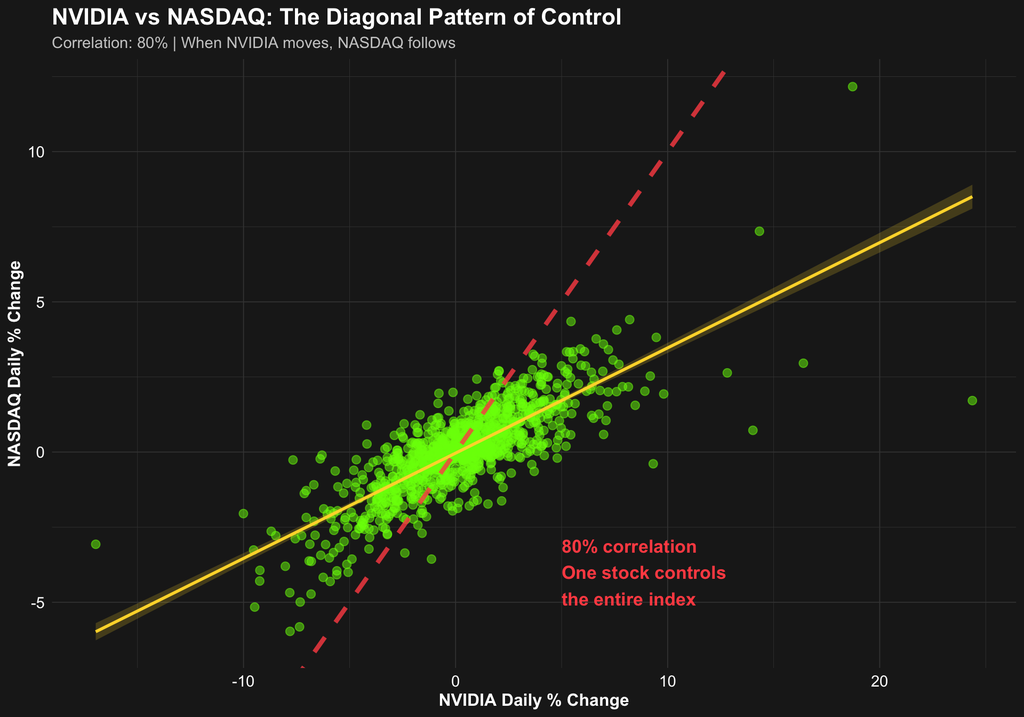

```r
# Prepare NVIDIA data with % changes (already done in setup, but recalculate for clarity)
nvda$pct_change <- (nvda$NVDA.Close - lag(nvda$NVDA.Close)) / lag(nvda$NVDA.Close) * 100

# Merge NVIDIA with NASDAQ
nvda_nasdaq <- merge(
  nvda %>% select(Date, nvda_change = pct_change),
  nasdaq %>% select(Date, nasdaq_change = pct_change),
  by = "Date"
) %>% na.omit()

# Calculate correlation
nvda_nasdaq_cor <- cor(nvda_nasdaq$nvda_change, nvda_nasdaq$nasdaq_change)

ggplot(nvda_nasdaq, aes(x = nvda_change, y = nasdaq_change)) +
  geom_point(alpha = 0.5, size = 2.5, color = "#76FF03") +

  # Add the "puppet string" - perfect correlation line
  geom_abline(slope = 1, intercept = 0, color = "#FF5252",
              size = 1.5, linetype = "dashed", alpha = 0.8) +

  # Add actual trend line
  geom_smooth(method = "lm", color = "#FDD835", fill = "#FDD835",
              alpha = 0.2, size = 1) +

  theme_minimal() +
  theme(
    plot.background = element_rect(fill = "#1e1e1e", color = NA),
    panel.background = element_rect(fill = "#1e1e1e", color = NA),
    panel.grid = element_line(color = "#424242", size = 0.3),
    text = element_text(color = "white"),
    axis.text = element_text(color = "white", size = 11),
    axis.title = element_text(color = "white", size = 12, face = "bold"),
    plot.title = element_text(size = 16, face = "bold"),
    plot.subtitle = element_text(size = 11, color = "#CCCCCC")
  ) +

  labs(
    title = "NVIDIA vs NASDAQ: The Diagonal Pattern of Control",
    subtitle = paste0("Correlation: ", round(nvda_nasdaq_cor * 100, 0),
                     "% | When NVIDIA moves, NASDAQ follows"),
    x = "NVIDIA Daily % Change",
    y = "NASDAQ Daily % Change"
  ) +

  annotate("text", x = 5, y = -4,
           label = paste0(round(nvda_nasdaq_cor * 100, 0), "% correlation\n",
                         "One stock controls\nthe entire index"),
           color = "#FF5252", size = 4.5, fontface = "bold", hjust = 0)
```

### Visualization 2D: All Three AI Giants

It’s not just NVIDIA. Let’s check Microsoft and Google too:

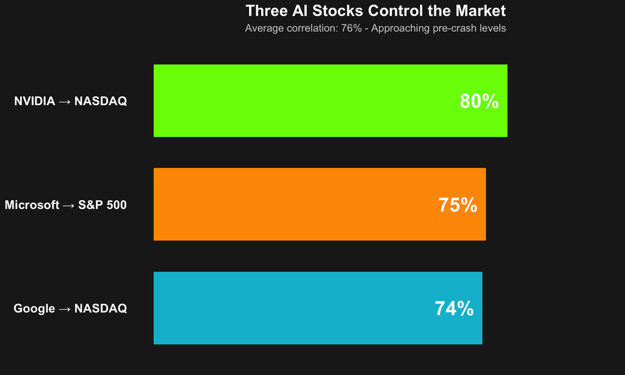

```r
# Create comparison data
ai_correlations <- data.frame(
  Label = c(
    paste0("NVIDIA → NASDAQ"),
    paste0("Microsoft → S&P 500"),
    paste0("Google → NASDAQ")
  ),
  Correlation = c(nvda_nasdaq_cor * 100, msft_sp_cor * 100, googl_nasdaq_cor * 100),
  Stock = c("NVIDIA", "Microsoft", "Google")
)

ggplot(ai_correlations, aes(x = reorder(Label, Correlation), y = Correlation, fill = Stock)) +
  geom_bar(stat = "identity", width = 0.7) +
  geom_text(aes(label = paste0(round(Correlation, 0), "%")),
            hjust = 1.2, color = "white", size = 8, fontface = "bold") +

  scale_fill_manual(values = c("NVIDIA" = "#76FF03", "Microsoft" = "#FF9800", "Google" = "#00BCD4")) +

  coord_flip() +

  theme_minimal() +
  theme(
    plot.background = element_rect(fill = "#1e1e1e", color = NA),
    panel.background = element_rect(fill = "#1e1e1e", color = NA),
    panel.grid = element_blank(),
    text = element_text(color = "white"),
    axis.text.y = element_text(color = "white", size = 14, hjust = 1, face = "bold"),
    axis.text.x = element_blank(),
    axis.title = element_blank(),
    plot.title = element_text(size = 18, face = "bold", hjust = 0.5),
    plot.subtitle = element_text(size = 12, color = "#CCCCCC", hjust = 0.5),
    legend.position = "none"
  ) +

  ylim(0, 100) +

  labs(
    title = "Three AI Stocks Control the Market",
    subtitle = "Average correlation: 76% - Approaching pre-crash levels"
  )
```

## Act 3: Your 401(k) is an AI Bet

“But I don’t own individual stocks,” you might think. “I have a diversified index fund.”

Let’s examine what’s actually in that fund and how it moves.

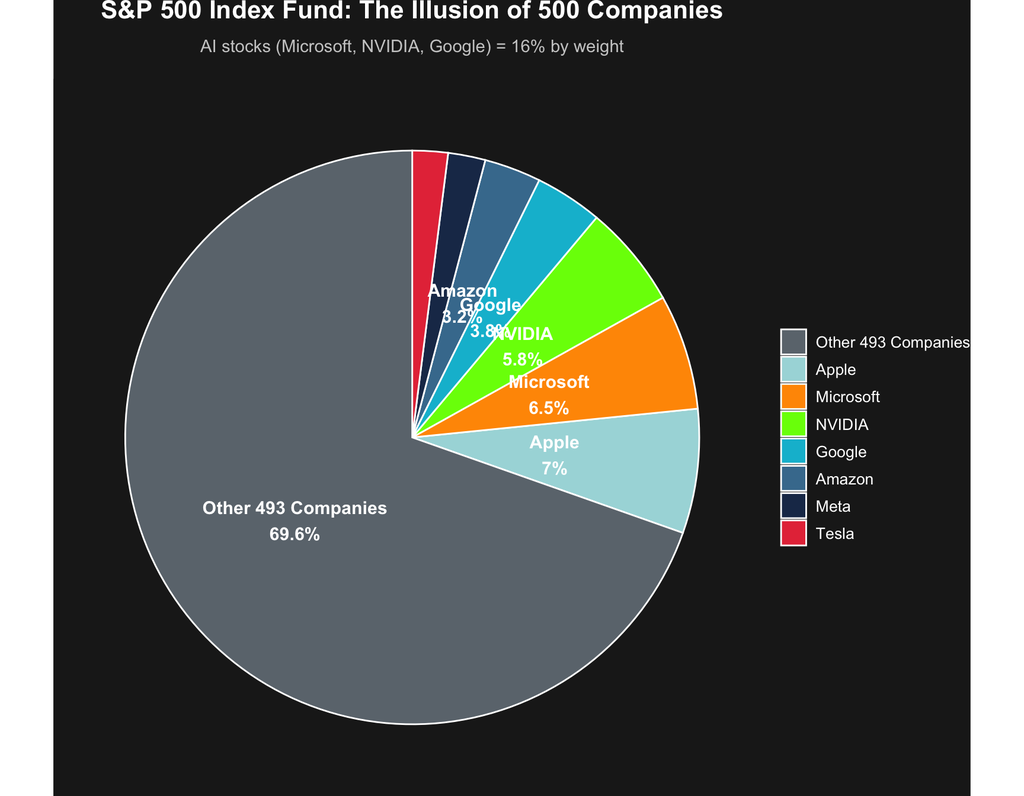

```r
# Top holdings in S&P 500
sp500_holdings <- data.frame(
  Company = c("Apple", "Microsoft", "NVIDIA", "Amazon", "Google",
              "Meta", "Tesla", "Other 493 Companies"),
  Weight = c(7.0, 6.5, 5.8, 3.2, 3.8, 2.1, 2.0, 69.6),
  Type = c("Tech", "AI", "AI", "Tech", "AI", "Tech", "Tech", "Other")
)

sp500_holdings$Company <- factor(sp500_holdings$Company,
                                  levels = sp500_holdings$Company[order(sp500_holdings$Weight, decreasing = TRUE)])

ggplot(sp500_holdings, aes(x = "", y = Weight, fill = Company)) +
  geom_bar(stat = "identity", width = 1, color = "white", size = 0.5) +
  coord_polar("y", start = 0) +

  scale_fill_manual(values = c(
    "Apple" = "#A8DADC",
    "Microsoft" = "#FF9800",
    "NVIDIA" = "#76FF03",
    "Amazon" = "#457B9D",
    "Google" = "#00BCD4",
    "Meta" = "#1D3557",
    "Tesla" = "#E63946",
    "Other 493 Companies" = "#6C757D"
  )) +

  geom_text(aes(label = ifelse(Weight > 2.5, paste0(Company, "\n", Weight, "%"), "")),
            position = position_stack(vjust = 0.5),
            color = "white", size = 4, fontface = "bold") +

  theme_void() +
  theme(
    plot.background = element_rect(fill = "#1e1e1e", color = NA),
    panel.background = element_rect(fill = "#1e1e1e", color = NA),
    text = element_text(color = "white"),
    plot.title = element_text(size = 16, face = "bold", hjust = 0.5, margin = margin(b = 10)),
    plot.subtitle = element_text(size = 11, color = "#CCCCCC", hjust = 0.5, margin = margin(b = 15)),
    legend.position = "right",
    legend.text = element_text(color = "white", size = 10),
    legend.title = element_blank()
  ) +

  labs(
    title = "S&P 500 Index Fund: The Illusion of 500 Companies",
    subtitle = "AI stocks (Microsoft, NVIDIA, Google) = 16% by weight"
  )
```

**At first glance:** AI stocks are only 16% of the index. That seems manageable, right?

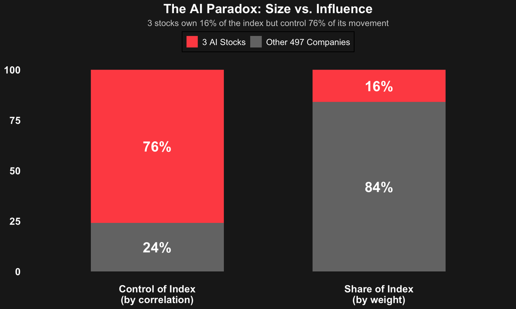

```r
paradox_data <- data.frame(
  Metric = c("Share of Index\n(by weight)", "Control of Index\n(by correlation)"),
  AI_Stocks = c(16, 76),
  Other_497 = c(84, 24)
)

paradox_long <- paradox_data %>%
  pivot_longer(cols = c(AI_Stocks, Other_497),
               names_to = "Group",
               values_to = "Percentage")

ggplot(paradox_long, aes(x = Metric, y = Percentage, fill = Group)) +
  geom_bar(stat = "identity", position = "stack", width = 0.6) +
  geom_text(aes(label = paste0(Percentage, "%")),
            position = position_stack(vjust = 0.5),
            color = "white", size = 7, fontface = "bold") +

  scale_fill_manual(
    values = c("AI_Stocks" = "#FF5252", "Other_497" = "#757575"),
    labels = c("3 AI Stocks", "Other 497 Companies")
  ) +

  theme_minimal() +
  theme(
    plot.background = element_rect(fill = "#1e1e1e", color = NA),
    panel.background = element_rect(fill = "#1e1e1e", color = NA),
    panel.grid = element_blank(),
    text = element_text(color = "white"),
    axis.text = element_text(color = "white", size = 14, face = "bold"),
    axis.title = element_blank(),
    plot.title = element_text(size = 18, face = "bold", hjust = 0.5),
    plot.subtitle = element_text(size = 12, color = "#CCCCCC", hjust = 0.5),
    legend.position = "top",
    legend.background = element_rect(fill = "#1e1e1e"),
    legend.text = element_text(color = "white", size = 12),
    legend.title = element_blank()
  ) +

  ylim(0, 100) +

  labs(
    title = "The AI Paradox: Size vs. Influence",
    subtitle = "3 stocks own 16% of the index but control 76% of its movement"
  )
```

**The paradox explained:**

Think of it like a classroom: - There are 500 students (companies) in the school (S&P 500) - 3 students are in the “AI Club” (NVIDIA, Microsoft, Google) - Those 3 kids are only 16% of the students - **But when those 3 decide to skip class, 76% of the school follows them**

**That’s influence vs. size.**

Your “diversified” 401(k) isn’t diversified at all. When AI sentiment shifts, your retirement savings shift—regardless of what the other 497 companies are doing. Here’s the concerning part: **as AI becomes MORE essential to business, concentration will INCREASE.**

Here’s the concerning part: **as AI becomes MORE essential to business, concentration will INCREASE.**

### The Vicious Cycle:

**Stage 1 (Now):** - AI stocks = 16% of S&P by weight - AI stocks = 76% correlation with market - Concentration already dangerous

**Stage 2 (Near Future):** - Every company NEEDS AI infrastructure - NVIDIA chips in every data center - Microsoft/Google AI in every business - Dependency increases → concentration increases

**Stage 3 (Crisis Point):** - AI stocks reach 25%+ of index - Correlation approaches 85-90% - When AI stumbles, entire economy stumbles

**Stage 4 (The Crash):** - Retirement accounts have no escape - Index funds get destroyed - The people who trusted “diversification” lose the most

**The paradox:** AI’s success guarantees its eventual systemic risk. The more essential it becomes, the more dangerous the concentration.

We set out to answer: **Is today’s market truly diversified?**

The data tells a clear story: **No.**

### The Takeaways

**For Individual Investors:** 1. Your “diversified” index fund isn’t diversified within stocks 2. You’re making a concentrated AI bet whether you know it or not 3. True diversification requires going OUTSIDE stocks (bonds, real estate, international)

**For the Market:** 1. Concentration breeds systemic risk 2. History shows this pattern ends badly 3. As AI becomes MORE essential, the problem gets WORSE